# STAT6014 Chapter 1

Jason Chan

2/2/2020

# Analyzing Challenger Data

## EDA

```r
ca <-data.frame("Temp"=c(53,56,57,63,66,67,67,67,68,69,70,70,
70,70,72,73,75,75,76,76,78,79,80,81),
"Failure"=c(rep(1,3),rep(0,8),rep(1,3),rep(0,3),
1,rep(0,6)))

summary(ca)
```

```
      Temp          Failure
 Min.   :53.00   Min.   :0.0000
 1st Qu.:67.00   1st Qu.:0.0000
 Median :70.00   Median :0.0000
 Mean   :69.92   Mean   :0.2917
 3rd Qu.:75.25   3rd Qu.:1.0000
 Max.   :81.00   Max.   :1.0000
```

```r
ca
```

| Temp | Failure |
| --- | --- |
| 53 | 1 |
| 56 | 1 |
| 57 | 1 |
| 63 | 0 |
| 66 | 0 |
| 67 | 0 |
| 67 | 0 |
| 67 | 0 |
| 68 | 0 |
| 69 | 0 |

[output cut: 14 more lines]

```r
table(ca$Failure)
```

```
 0  1
17  7
```

A lot more 0’s than 1’s, imbalanced.

## Modelling using Logistric Regression

```r
# using glm2 function

fit <- glm2(formula = Failure~Temp, family = "binomial", data = ca)
summary(fit)
```

```
Call:
glm2(formula = Failure ~ Temp, family = "binomial", data = ca)

Deviance Residuals:
    Min       1Q   Median       3Q      Max
-1.2125  -0.8253  -0.4706   0.5907   2.0512

Coefficients:
            Estimate Std. Error z value Pr(>|z|)
(Intercept) 10.87535    5.70291   1.907   0.0565 .
Temp        -0.17132    0.08344  -2.053   0.0400 *
---
Signif. codes:  0 ‘***’ 0.001 ‘**’ 0.01 ‘*’ 0.05 ‘.’ 0.1 ‘ ’ 1

(Dispersion parameter for binomial family taken to be 1)

    Null deviance: 28.975  on 23  degrees of freedom
Residual deviance: 23.030  on 22  degrees of freedom
AIC: 27.03

Number of Fisher Scoring iterations: 4
```

- This implies that $\beta_0 = 10.87535$ and $\beta_1 = -0.17132$
- This means that the fitted model is $logit(\pi) = 10.87535-0.17132x$
- And the estimated probability $\pi_i = e^{10.87535 -0.17132x} / (1+e^{10.87535 -0.17132x})$

## Prediction

```r
plotdata<-data.frame(Temp = seq(50,85,0.1))
predicted <-predict(fit, newdata= plotdata, type = "response")
```

## Probability Plot

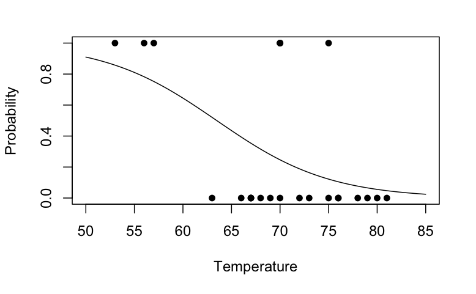

```r
plot(ca$Temp, ca$Failure, pch= 16, xlim= c(50,85), xlab= "Temperature", ylab= "Probability")
lines(plotdata$Temp, predicted)
```

Probality of break at Temp=50 Farenheit

```r
predict(fit, newdata= data.frame(Temp = c(50)), type = "response")
```

```
        1
0.9096463
```

## Interpreting the Parameters (Beta)

```r
cbind(OR=coef(fit), confint(fit))
```

```
                    OR      2.5 %     97.5 %
(Intercept) 10.8753491  1.1941770 24.9888102
Temp        -0.1713205 -0.3779407 -0.0305637
```

Need to exponential it to get the odds ratio

```r
exp(cbind(OR=coef(fit), confint(fit)))
```

```
                      OR     2.5 %       97.5 %
(Intercept) 5.285720e+04 3.3008401 7.120367e+10
Temp        8.425515e-01 0.6852711 9.698986e-01
```

Since the **odds ratio (OR)** of Temp is 0.843 < 1, Temp is associated with a decrease in odds of 16% for an increase of 1 unit in Temp.

```r
1 - 8.425515e-01
```

```
[1] 0.1574485
```

For an increase in 5F in Temp, would result in odd reduction of

```r
1 - exp(5*-0.1713205)
```

```
[1] 0.5753978
```

## Feature Selection using Likelihood Ratio Test

- Null Model: $logit(\pi) = \beta_0$
- Full Model: $logit(\pi) = \beta_0 + \beta_1x_1$

```r
# Null model
fitNull <- glm2(Failure~1, family = 'binomial', data = ca)
lrtest(fitNull, fit)
```

```
Likelihood ratio test

Model 1: Failure ~ 1
Model 2: Failure ~ Temp
  #Df  LogLik Df  Chisq Pr(>Chisq)
1   1 -14.487
2   2 -11.515  1 5.9441    0.01477 *
---
Signif. codes:  0 ‘***’ 0.001 ‘**’ 0.01 ‘*’ 0.05 ‘.’ 0.1 ‘ ’ 1
```

- Temperature is significant and should be included in full model

# Analyzing Neuralgia Patients Data

## EDA

```r
# Create dataframe for Neuralgia Patients data
npd <- data.frame("Trt"=c('A','B','P'),
                  "Pain"=c(4,5,15),
                  "NoPain"=c(16,15,5))

# set reference class of Trt to 'P' for reference coding
npd$Trt <- relevel(npd$Trt, ref='P')

npd
```

| Trt | Pain | NoPain |
| --- | --- | --- |
| A | 4 | 16 |
| B | 5 | 15 |
| P | 15 | 5 |

## Modelling

Note that data above is aggregated and will use a different syntax for model fitting as below:

```r
fit <- glm2(cbind(Pain, NoPain) ~ Trt, family = 'binomial', data=npd)
summary(fit)
```

```
Call:
glm2(formula = cbind(Pain, NoPain) ~ Trt, family = "binomial",
    data = npd)

Deviance Residuals:
[1]  0  0  0

Coefficients:
            Estimate Std. Error z value Pr(>|z|)
(Intercept)   1.0986     0.5164   2.127  0.03338 *
TrtA         -2.4849     0.7610  -3.265  0.00109 **
TrtB         -2.1972     0.7303  -3.009  0.00262 **
---
Signif. codes:  0 ‘***’ 0.001 ‘**’ 0.01 ‘*’ 0.05 ‘.’ 0.1 ‘ ’ 1

(Dispersion parameter for binomial family taken to be 1)

    Null deviance: 1.5758e+01  on 2  degrees of freedom
Residual deviance: 1.7764e-15  on 0  degrees of freedom
AIC: 15.436

Number of Fisher Scoring iterations: 3
```

- Hence, the fitted model is $logit(\pi_x)=1.0986 - 2.4849I_A - 2.1972I_B$
- The logits for each treatment are:
  - Treatment A: $logit(\pi_A)=1.0986 - 2.4849I_A=-1.3863$
  - Treatment B: $logit(\pi_B)=1.0986 - 2.1972I_B=-1.0986$
  - Placebo: $logit(\pi_P)=1.0986$

Their probabilities of Pain are:

```r
prob_func <- function(x){
  return(exp(x)/(1+exp(x)))
}

prob_func(c(-1.3863, -1.0986, 1.0986))
```

```
[1] 0.1999991 0.2500023 0.7499977
```

Placebo still gives high prob of pain compared to treatment A and B

Odds ratio of A to B:

```r
exp(-2.4849 - (-2.1972))
```

```
[1] 0.7499866
```

Hence, a 25% reduction in odds of pain by treatment A compared to B.

Odds ratio of A to Placebo:

```r
exp(-2.4849)
```

```
[1] 0.08333389
```

```r
glue("reduction of {1- exp(-2.4849)} in odds")
```

```
reduction of 0.916666112515824 in odds
```

Odds Reduction:

```r
exp(cbind(OR=coef(fit), confint(fit)))
```

```
                    OR      2.5 %    97.5 %
(Intercept) 3.00000000 1.16234573 9.2245900
TrtA        0.08333333 0.01653094 0.3398993
TrtB        0.11111111 0.02395103 0.4335703
```

Obviously Treatment A has the highest reduction in odds.

## Feature Selection using Likelihood Ratio Test

- $H_0: \beta_1 = \beta_2 = 0$
  - Testing if A and B are the same as placebo
  - All 3 are indifferent in treating pain
  - Comparing all 3 treatments, not just one to another
- Null Model: $logit(\pi) = \beta_0$
- Full Model: $logit(\pi) = \beta_0 + \beta_1 I_{x=A} + \beta_2 I_{x=B}$ (using Placebo as reference group)

```r
fitNull <- glm2(cbind(Pain, NoPain)~1, family = 'binomial', data=npd)
lrtest(fitNull, fit)
```

```
Likelihood ratio test

Model 1: cbind(Pain, NoPain) ~ 1
Model 2: cbind(Pain, NoPain) ~ Trt
  #Df  LogLik Df  Chisq Pr(>Chisq)
1   1 -12.597
2   3  -4.718  2 15.758  0.0003785 ***
---
Signif. codes:  0 ‘***’ 0.001 ‘**’ 0.01 ‘*’ 0.05 ‘.’ 0.1 ‘ ’ 1
```

# Analyzing Prison Sentencing Data

```r
# Create dataframe for Prison Sentencing data
psd <- data.frame("ibus"=c(1,1,0,0),
                  "iprior"=c(0,1,0,1),
                  "prison"=c(17,42,54,33),
                  "noprison"=c(75,109,359,175)) ; psd
```

| ibus | iprior | prison | noprison |
| --- | --- | --- | --- |
| 1 | 0 | 17 | 75 |
| 1 | 1 | 42 | 109 |
| 0 | 0 | 54 | 359 |
| 0 | 1 | 33 | 175 |

## Fit Additive Logistic Regression Model

- Test if prior arrest and crime type is related to prison sentencing

```r
additive <- glm2(cbind(prison, noprison)~ibus+iprior, family = 'binomial', data = psd)

summary(additive)
```

```
Call:
glm2(formula = cbind(prison, noprison) ~ ibus + iprior, family = "binomial",
    data = psd)

Deviance Residuals:
      1        2        3        4
-0.4989   0.3500   0.2814  -0.3568

Coefficients:
            Estimate Std. Error z value Pr(>|z|)
(Intercept)  -1.9356     0.1374 -14.082  < 2e-16 ***
ibus          0.5835     0.1964   2.971  0.00297 **
iprior        0.3345     0.1901   1.760  0.07839 .
---
Signif. codes:  0 ‘***’ 0.001 ‘**’ 0.01 ‘*’ 0.05 ‘.’ 0.1 ‘ ’ 1

(Dispersion parameter for binomial family taken to be 1)

    Null deviance: 16.0740  on 3  degrees of freedom
Residual deviance:  0.5779  on 1  degrees of freedom
AIC: 27.166

Number of Fisher Scoring iterations: 3
```

- Small deviance indicates model is sufficient to fit data
- LRT statistic is 16.0740 - 0.5779 = 15.4961

## Compare fitting 1 variable with 2

```r
fit2 <- glm2(cbind(prison, noprison)~ibus, family = 'binomial', data = psd)

summary(fit2)
```

```
Call:
glm2(formula = cbind(prison, noprison) ~ ibus, family = "binomial",
    data = psd)

Deviance Residuals:
      1        2        3        4
-1.3379   0.9975  -0.5525   0.7576

Coefficients:
            Estimate Std. Error z value Pr(>|z|)
(Intercept)  -1.8145     0.1156 -15.694  < 2e-16 ***
ibus          0.6771     0.1891   3.581 0.000342 ***
---
Signif. codes:  0 ‘***’ 0.001 ‘**’ 0.01 ‘*’ 0.05 ‘.’ 0.1 ‘ ’ 1

(Dispersion parameter for binomial family taken to be 1)

    Null deviance: 16.0740  on 3  degrees of freedom
Residual deviance:  3.6643  on 2  degrees of freedom
AIC: 28.252

Number of Fisher Scoring iterations: 4
```

```r
fitNull <- glm2(cbind(prison, noprison)~1, family = 'binomial', data = psd)

lrtest(fitNull, additive)
```

```
Likelihood ratio test

Model 1: cbind(prison, noprison) ~ 1
Model 2: cbind(prison, noprison) ~ ibus + iprior
  #Df  LogLik Df  Chisq Pr(>Chisq)
1   1 -18.331
2   3 -10.583  2 15.496  0.0004316 ***
---
Signif. codes:  0 ‘***’ 0.001 ‘**’ 0.01 ‘*’ 0.05 ‘.’ 0.1 ‘ ’ 1
```

```r
lrtest(fit2, additive)
```

```
Likelihood ratio test

Model 1: cbind(prison, noprison) ~ ibus
Model 2: cbind(prison, noprison) ~ ibus + iprior
  #Df  LogLik Df  Chisq Pr(>Chisq)
1   2 -12.126
2   3 -10.583  1 3.0864    0.07895 .
---
Signif. codes:  0 ‘***’ 0.001 ‘**’ 0.01 ‘*’ 0.05 ‘.’ 0.1 ‘ ’ 1
```

- The slight difference is Log likelihood and based on ChiSq statistic, iprior is marginally insignificant.

# Aircraft Damage Data Analysis

## EDA

```r
# Read Aircraft Damage data
aircraft <-read.csv(file="/Users/jasonchan/MSTAT/STAT6014_Advanced_Stat_Model/data/aircraft.csv", header=TRUE,sep=",") ; aircraft
```

| y | x1 | x2 | x3 |
| --- | --- | --- | --- |
| 0 | 0 | 4 | 91.5 |
| 1 | 0 | 4 | 84.0 |
| 0 | 0 | 4 | 76.5 |
| 0 | 0 | 5 | 69.0 |
| 0 | 0 | 5 | 61.5 |
| 0 | 0 | 5 | 80.0 |
| 1 | 0 | 6 | 72.5 |
| 0 | 0 | 6 | 65.0 |
| 0 | 0 | 6 | 57.5 |
| 2 | 0 | 7 | 50.0 |

[output cut: 20 more lines]

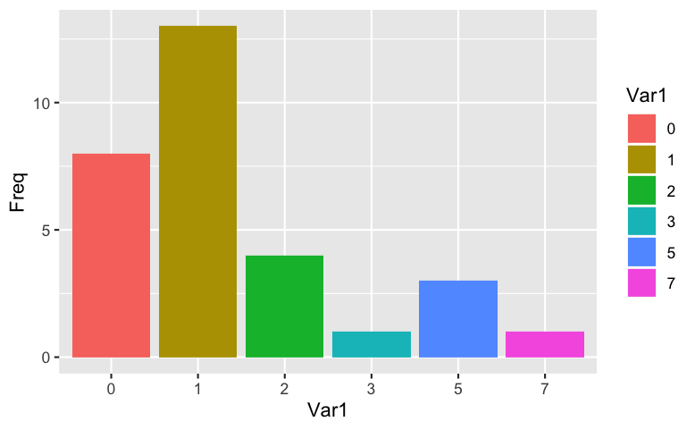

```r
aircraft_df <- as.data.frame(table(as.factor(aircraft$y)))

ggplot(aircraft_df, aes(fill=Var1, y=Freq, x=Var1)) +
    geom_bar(position="dodge", stat="identity")
```

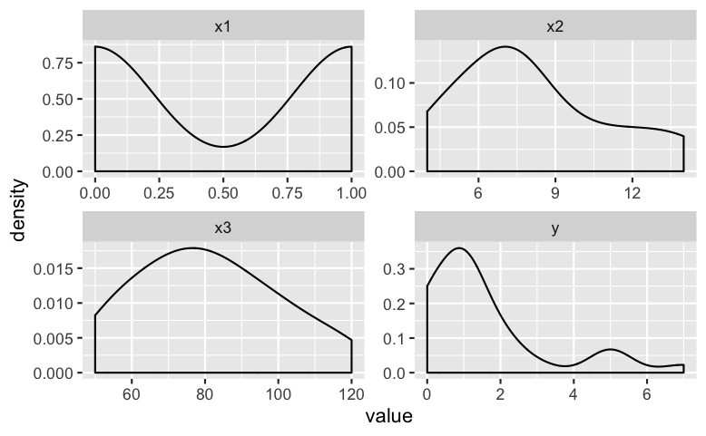

```r
aircraft %>%
  keep(is.numeric) %>%                     # Keep only numeric columns
  gather() %>%                             # Convert to key-value pairs
  ggplot(aes(value)) +                     # Plot the values
    facet_wrap(~ key, scales = "free") +   # In separate panels
    geom_density()                         # as density
```

- Model the response as a Poisson dist and as a function of linear combination of the independent variables
- Assume that the log of the mean is related with linear combination of predictors
- $log(\mu(x)) = x^{'}\beta = \beta_0 + \beta_1x_1 + ...+\beta_px_p$

## Modelling

```r
fit <- glm2(y~x1+x2+x3, family = "poisson", data = aircraft)
summary(fit)
```

```
Call:
glm2(formula = y ~ x1 + x2 + x3, family = "poisson", data = aircraft)

Deviance Residuals:
    Min       1Q   Median       3Q      Max
-1.6418  -1.0064  -0.0180   0.5581   1.9094

Coefficients:
             Estimate Std. Error z value Pr(>|z|)
(Intercept) -0.406023   0.877489  -0.463   0.6436
x1           0.568772   0.504372   1.128   0.2595
x2           0.165425   0.067541   2.449   0.0143 *
x3          -0.013522   0.008281  -1.633   0.1025
---
Signif. codes:  0 ‘***’ 0.001 ‘**’ 0.01 ‘*’ 0.05 ‘.’ 0.1 ‘ ’ 1

(Dispersion parameter for poisson family taken to be 1)

    Null deviance: 53.883  on 29  degrees of freedom
Residual deviance: 25.953  on 26  degrees of freedom
AIC: 87.649

Number of Fisher Scoring iterations: 5
```

- Fitted model is then $log(\mu(x)) = -0.406023 + 0.568772x_1 + 0.165425x_2 - 0.013522x_3$
- Note that x1 and x3 are insignificant
- p-values are from a Wald’s test, might be less accurate in terms of significance, do a type 3 LR test

## Type 3 Analysis by LR Test

- Similar to doing a backward elimination process

```r
drop1(fit, test = "LR")
```

```
Single term deletions

Model:
y ~ x1 + x2 + x3
       Df Deviance    AIC    LRT Pr(>Chi)
<none>      25.953 87.649
x1      1   27.220 86.916 1.2667   0.2604
x2      1   32.192 91.888 6.2386   0.0125 *
x3      1   28.634 88.330 2.6811   0.1015
---
Signif. codes:  0 ‘***’ 0.001 ‘**’ 0.01 ‘*’ 0.05 ‘.’ 0.1 ‘ ’ 1
```

- In this case, x1 is most insignificant, drop it

```r
fit2 <- glm2(y~x2+x3, family = poisson, data = aircraft)
drop1(fit2, test = "LR")
```

```
Single term deletions

Model:
y ~ x2 + x3
       Df Deviance     AIC     LRT  Pr(>Chi)
<none>      27.220  86.916
x2      1   50.537 108.233 23.3174 1.374e-06 ***
x3      1   29.206  86.902  1.9861    0.1588
---
Signif. codes:  0 ‘***’ 0.001 ‘**’ 0.01 ‘*’ 0.05 ‘.’ 0.1 ‘ ’ 1
```

- It seems x3 is insignificant, but p value higher than before, indicating signs of multicollinearity
- Use glmulti for exhaustive search

## Exhaustive search with `glmulti`

```r
# compare all possible models
fitall <- glmulti(y~x1+x2+x3, family = poisson, data = aircraft,
                  level = 1, method = "h", crit = "aicc")

# print brief summary
print(fitall)

# fit best model
fitbest <- glm2(y~x2, family = poisson, data = aircraft)
summary(fitbest)
```

[output not shown]

- refer to lecture notes

# Mine Fracture Data

## EDA

```r
# Read Mine Fractures data
mine <-read.csv(file="mine.csv", header=TRUE,sep=",")

# compare all possible models
fitall <- glmulti(y~x1+x2+x3+x4, family = poisson, data = mine,
                  level = 1, method = "h", crit = "aicc")

# print brief summary
print(fitall)

# print AICc for all models
weightable(fitall)

# fit best model
fitbest <- glm2(y~x1+x2+x4, family = poisson, data = mine)
summary(fitbest)
```

[output not shown]